# Counterfactual Example

Simon Brewer

5/25/2023

Examples taken from chapter 8 of The Book Of Why (Pearl, 2019)

## Libraries and whatnot

```r
library(tidyverse)
# library(broom)
library(patchwork)
library(scales)
library(dagitty)
library(ggdag)
library(latex2exp)  # Easily convert LaTeX into arcane plotmath expressions
library(ggtext)     # Use markdown in ggplot labels

# Create a cleaner serifed theme to use throughout
theme_do_calc <- function() {
  theme_dag(base_family = "Times New Roman") +
    theme(plot.title = element_text(size = rel(1.5)),
          plot.subtitle = element_markdown())
}

# Make all geom_dag_text() layers use these settings automatically
update_geom_defaults(ggdag:::GeomDagText, list(family = "Times New Roman",
                                               fontface = "bold",
                                               color = "black"))
```

## Salary example

Data are

- `EX`: number of years of experience
- `ED`: Education level (0 = BS; 1 = MS; 2 = PhD)
- `S`: Salary in `$`

### Directed acyclic graph

The graph is set up as a fork, with education impacting both experience and salary:

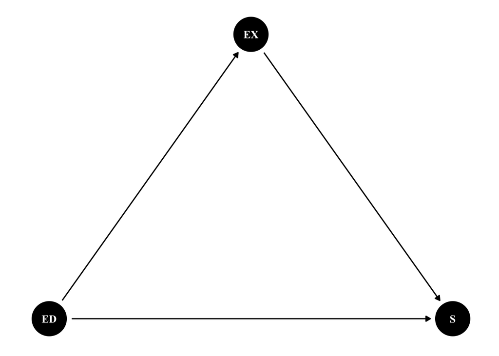

```r
dag1 <- dagify(EX ~ ED,
               S ~ EX + ED,
               coords = list(x = c(ED = 1, EX = 2, S = 3),
                             y = c(ED = 1, EX = 2, S = 1)),
               exposure = "EX",
               outcome = "S")

ggdag(dag1) +
  theme_dag()
```

Equations are:

$$EX = f(ED)$$
$$S = f(ED, EX)$$

For a counterfactual analysis, we extend this to include unobserved variables ($U_x$):

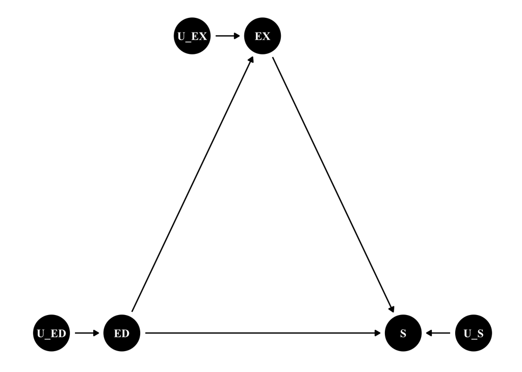

```r
pcm_dag <- dagify(ED ~ U_ED,
               EX ~ ED + U_EX,
               S ~ EX + ED + U_S,
               coords = list(x = c(ED = 1, EX = 2, S = 3,
                                   U_ED = 0.5, U_EX = 1.5, U_S = 3.5),
                             y = c(ED = 1, EX = 2, S = 1,
                                   U_ED = 1, U_EX = 2, U_S = 1)),
               exposure = "EX",
               outcome = "S", latent = c("U_ED", "U_EX", "U_S"))

ggdag(pcm_dag) +
  theme_dag()
```

Equations are:

$$ED = f(U_{ED})$$
$$EX = f(ED, U_{EX})$$

$$S = f(ED, EX, U_{S})$$
From Pearl: “We know these variables exist (e.g. Alice is a friend of the company’s president) but they are too diverse and too numerous to incorporate explicitly…”

## Data

We start with two equations

$$ED = U_{ED} = [0,1,2]$$

$$EX= 10 - 4 \times ED + U_{EX}$$

$$S=65,000 + 2,500 \times EX + 5,000 \times ED + U_{S}$$

### Simulated data

1. `ED`:

```r
n = 1000
ED = sample(c(0,1,2), size = n, replace = TRUE,
            prob = c(0.6, 0.3, 0.1))

table(ED)
```

```
## ED
##   0   1   2
## 600 308  92
```

2. `EX`:

```r
U_EX = rpois(n, lambda = 2) - 2
EX = 10 - 4 * ED + U_EX
table(EX)
```

```
## EX
##   0   1   2   3   4   5   6   7   8   9  10  11  12  13  14  15
##  12  23  22  21  38  96  88  62 103 172 166 114  52  18  12   1
```

3. `S`:

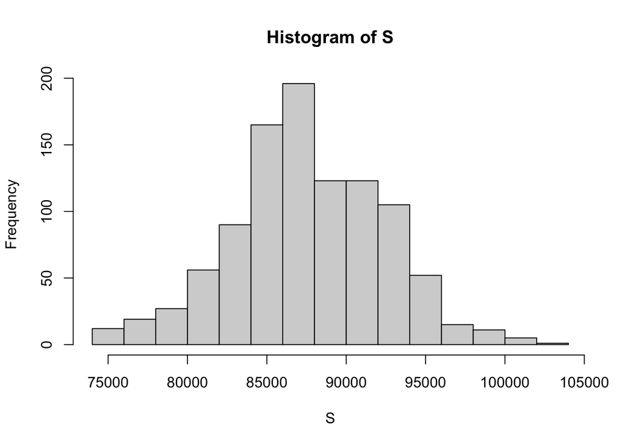

```r
U_S = rnorm(n, 0, 500)
S = 65000 + 2500 * EX + 5000 * ED + U_S
hist(S)
```

### Plots

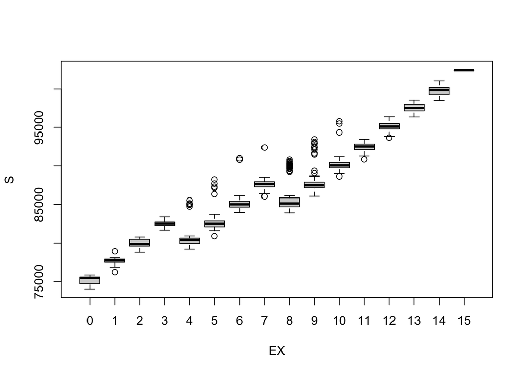

```r
boxplot(S ~ EX)
```

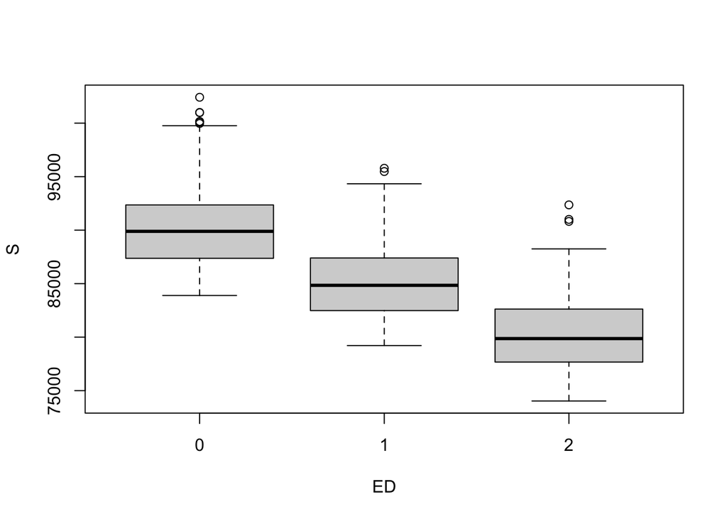

```r
boxplot(S ~ ED)
```

## Adjustment

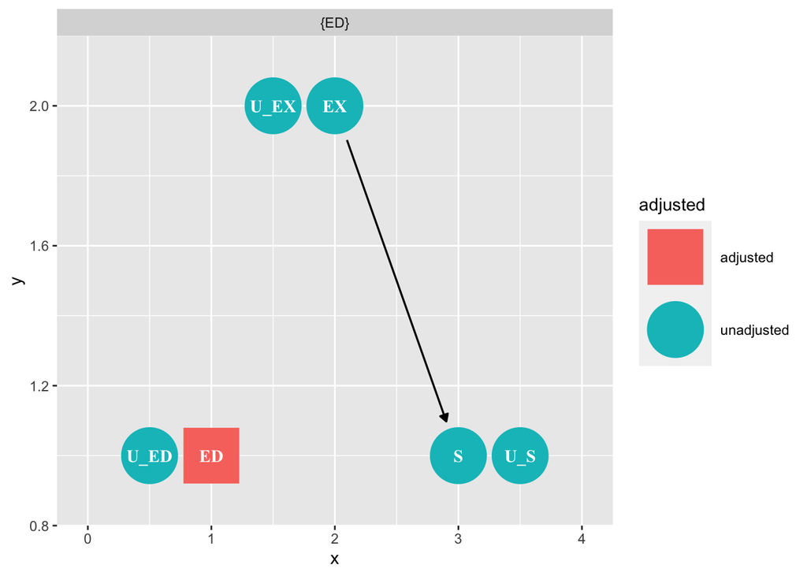

```r
ggdag_adjustment_set(pcm_dag)
```

Naive model

```r
fit_S <- lm(S ~ EX)
summary(fit_S)
```

```
##
## Call:
## lm(formula = S ~ EX)
##
## Residuals:
##     Min      1Q  Median      3Q     Max
## -3627.7 -1191.0  -110.6  1047.1  6504.7
##
## Coefficients:
##             Estimate Std. Error t value            Pr(>|t|)
## (Intercept) 75438.82     150.61  500.89 <0.0000000000000002 ***
## EX           1510.06      17.56   85.98 <0.0000000000000002 ***
## ---
## Signif. codes:  0 '***' 0.001 '**' 0.01 '*' 0.05 '.' 0.1 ' ' 1
##
## Residual standard error: 1640 on 998 degrees of freedom
## Multiple R-squared:  0.8811, Adjusted R-squared:  0.8809
## F-statistic:  7393 on 1 and 998 DF,  p-value: < 0.00000000000000022
```

Adjusted model

```r
fit_S <- lm(S ~ EX + ED)
summary(fit_S)
```

```
##
## Call:
## lm(formula = S ~ EX + ED)
##
## Residuals:
##      Min       1Q   Median       3Q      Max
## -1653.76  -347.30    11.03   373.17  1862.89
##
## Coefficients:
##             Estimate Std. Error t value            Pr(>|t|)
## (Intercept) 64993.14     118.36  549.11 <0.0000000000000002 ***
## EX           2500.20      11.66  214.34 <0.0000000000000002 ***
## ED           5028.53      52.29   96.16 <0.0000000000000002 ***
## ---
## Signif. codes:  0 '***' 0.001 '**' 0.01 '*' 0.05 '.' 0.1 ' ' 1
##
## Residual standard error: 511.9 on 997 degrees of freedom
## Multiple R-squared:  0.9884, Adjusted R-squared:  0.9884
## F-statistic: 4.257e+04 on 2 and 997 DF,  p-value: < 0.00000000000000022
```

Model for experience

```r
fit_EX = lm(EX ~ ED)
summary(fit_EX)
```

```
##
## Call:
## lm(formula = EX ~ ED)
##
## Residuals:
##     Min      1Q  Median      3Q     Max
## -2.0838 -0.9979 -0.0408  0.9592  5.0021
##
## Coefficients:
##             Estimate Std. Error t value            Pr(>|t|)
## (Intercept)  9.99785    0.05483  182.35 <0.0000000000000002 ***
## ED          -3.95702    0.06669  -59.34 <0.0000000000000002 ***
## ---
## Signif. codes:  0 '***' 0.001 '**' 0.01 '*' 0.05 '.' 0.1 ' ' 1
##
## Residual standard error: 1.389 on 998 degrees of freedom
## Multiple R-squared:  0.7792, Adjusted R-squared:  0.7789
## F-statistic:  3521 on 1 and 998 DF,  p-value: < 0.00000000000000022
```

## Naive counterfactual

The standard way to estimate Alice’s salary if she went to college would be to create a new’instance’ for Alice with $ED=1$ and predict for that:

```r
alice_ed1 = data.frame(ED = 1, EX = 6, S = 81000)
pred_naive = predict(fit_S, alice_ed1)
pred_naive
```

```
##        1
## 85022.89
```

Or an change in salary of 4023. But this ignores the confounding effect of `ED` on `EX` as we will see below.

## Counterfactual

### Set up individual to calculate counterfactual for:

```r
alice = data.frame(ED = 0, EX = 6, S = 81000)
```

### Get ‘idiosyncratic factors’ (i.e. predicted errors)

```r
(alice_us = alice$S - predict(fit_S, alice))
```

```
##        1
## 1005.639
```

```r
(alice_uex = alice$EX - predict(fit_EX, alice))
```

```
##         1
## -3.997852
```

This tells us that Alice salary is different from the expected value ($E(S)$) by roughly 1006 dollars and her experience is different from $E(EX)$ by -4 years.

### Calculate counterfactual if Alice went to college

First, what would the experience be, if Alice went to college ($EX_{ED=1}$), given $\beta_0 \approx 10$ and $\beta_1 \approx -4$ in `fit_EX`

$$EX_{ED=1}(\mbox{Alice}) = \beta_0 + \beta_1 \times 1 + U_{EX}$$

$$EX_{ED=1}(\mbox{Alice}) = 10 + (-4 \times 1) -4 = 2$$

The fact that Alice went to college reduces her experience from 6 years to 2. We can also get this from the data:

```r
ex_ed1 = predict(fit_EX, alice_ed1) + alice_uex
ex_ed1
```

```
##        1
## 2.042983
```

From the model we get a roughly equivalent change from 6 to 2 years of experience.

With this change,m we can now plug all of the numbers into the salary equation (including the two idosyncratic factors):

$$S_{ED=1)(\mbox{Alice})} = \beta_0 + \beta_1 \times
EX_{ED=1}(\mbox{Alice}) + \beta_2 \times ED_{ED=1}(\mbox{Alice}) +
U_S(\mbox{Alice})$$

```r
alice_ed1 = data.frame(ED = 1, EX = ex_ed1, S = 81000)
pred_cf = predict(fit_S, alice_ed1) + alice_us
pred_cf
```

```
##        1
## 76135.18
```

Giving a final results of 76135 dollars, which is 8888 less than the naive prediction